# occ_ab

This notebook contains the code to reproduce Figure 2 and Supplementary Figures 4 & 5

Load libraries

```r
source("../../General/facet_zoom_patch.R")
source("../../General/general_functions.R")
library(vegan)
library(ggforce)
library(eulerr)
library(ggalluvial)
library(tidyverse)
```

Load data

```r
otu <- readRDS("../Data/virome_tpm_75_mtx.RDS")
otu.tidy <- readRDS("../Data/virome_tpm_75_tidy.RDS")
map <- readRDS("../Data/full_map.RDS") %>% filter(Keep)
pal <- c(RColorBrewer::brewer.pal(9, "Reds")[6],RColorBrewer::brewer.pal(9, "Blues")[6])
```

Separate virome and total metagenome (bulk) datasets

```r
v.map <- filter(map, Extraction == "VFD")
v.ids <- readRDS("../Data/vir_ids.RDS")

v.otu.tidy <- otu.tidy %>%
  inner_join(v.map, by = "SampleID")
v.otu <- otu[rownames(otu) %in% v.ids, colnames(otu) %in% v.map$SampleID]
v.otu <- v.otu[rowSums(v.otu)>0,]


b.map <- filter(map, Extraction == "BULK")
b.ids <- readRDS("../Data/bulk_ids.RDS")

b.otu.tidy <- otu.tidy %>%
  inner_join(b.map, by = "SampleID")
b.otu <- otu[rownames(otu) %in% b.ids, colnames(otu) %in% b.map$SampleID]
b.otu <- b.otu[rowSums(b.otu)>0,]
```

Get the accumulation curves for both datasets and reformat

```r
v.sp <- specaccum(t(v.otu), method = "random", permutations = 100)
v.perm <- v.sp$perm
v.perm.tidy <- as.tibble(v.perm) %>%
  mutate(Sites = 1:nrow(.)) %>%
  gather(key = "Permutation", value = "Species", -Sites)
```

```
`as.tibble()` is deprecated as of tibble 2.0.0.
Please use `as_tibble()` instead.
The signature and semantics have changed, see `?as_tibble`.
Using compatibility `.name_repair`.
```

```r
v.richness <- data.frame(Sites = v.sp$sites, Species = v.sp$richness)

b.sp <- specaccum(t(b.otu), method = "random", permutations = 100)
b.perm <- b.sp$perm
b.perm.tidy <- as.tibble(b.perm) %>%
  mutate(Sites = 1:nrow(.)) %>%
  gather(key = "Permutation", value = "Species", -Sites)
b.richness <- data.frame(Sites = b.sp$sites, Species = b.sp$richness)
```

Plot accumulation curves

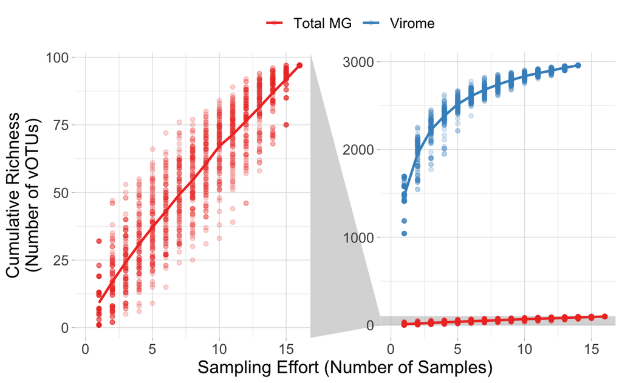

```r
perm.tidy <- rbind(mutate(b.perm.tidy, Extraction = "Total MG"),
                   mutate(v.perm.tidy, Extraction = "Virome"))

richness <- rbind(mutate(b.richness, Extraction = "Total MG"),
                  mutate(v.richness, Extraction = "Virome"))

acc.p <- ggplot(perm.tidy, aes(Sites, Species, color = Extraction)) +
  geom_point(alpha = 0.2) +
  geom_line(data = richness, size = 1) +
  facet_zoom(y = Extraction == "Total MG", zoom.size = 1, show.area = T) +
  scale_color_manual(name = "", values = pal) +
  xlim(0,16) +
  ylab("Cumulative Richness\n(Number of vOTUs)") +
  xlab("Sampling Effort (Number of Samples)") +
  theme_light() +
  theme(text = element_text(size = 15),
        legend.position = "top",
        panel.border = element_blank())

acc.p
```

Plot Euler diagram

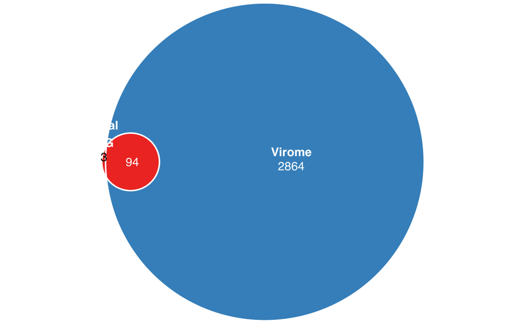

```r
euler.p <- plot(euler(list("Total\nMG" = b.ids, Virome = v.ids)),
     fills = pal[c(1,2,1)],
     edges = list(col = c("white", "white"), lex = 2),
     labels = list(fontfamily = "Helvetica",
                   col = c("white", "white", "black"),
                   cex = 1),
     quantities = list(fontfamily = "Helvetica",
                   col = c("black", "white", "white"),
                   cex = 1))

euler.p
```

This section corresponds to Figure 2 and show the abundance-occupancy patterns of all vOTUs derived from viromes (in blue), and the abundance-occupancy patterns of the set of 94 vOTUs detected in both viromes and Total MGs (red) Calculate occupancy and abundance within month subsets (occ.df.month) and identify which vOTUs were present in each month for both profiling methods (sets.per.month)

```r
sets.per.month <- otu.tidy %>%
  inner_join(map, by = "SampleID") %>%
  filter(Abundance > 0) %>%
  group_by(Method, Month, OTU_ID) %>%
  count() %>%
  group_by(Month, OTU_ID) %>%
  mutate(Total = n()) %>%
  ungroup() %>%
  mutate(Set = ifelse(Total == "2", "Both", Method)) %>%
  group_by(Month, OTU_ID, Set) %>%
  count() %>%
  select(-n)

v.occ.df.month <- v.otu.tidy %>%
  group_by(SampleID) %>%
  mutate(RelAbundance = Abundance/sum(Abundance)) %>%
  group_by(Month, OTU_ID) %>%
  summarise(Occupancy = sum(Abundance > 0),
            Occupancy2 = sum(Abundance > 0)/n() * 100,
            MeanAbundance = mean(RelAbundance),
            MeanRelAbundance = mean(RelAbundance)) %>%
  filter(Occupancy > 0) %>%
  inner_join(sets.per.month, by = c("Month", "OTU_ID"))
```

Plot abundance-occupancy curve

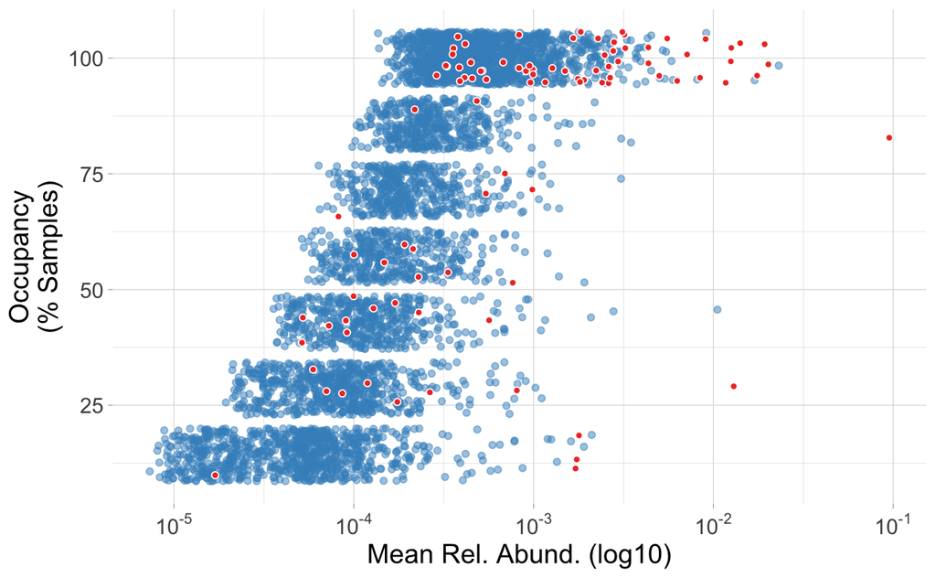

```r
v.curve.p <- v.occ.df.month %>%
  ggplot(aes(MeanAbundance, Occupancy2)) +
  geom_jitter(data = filter(v.occ.df.month, Set == "Virome"), color = pal[2], alpha = 0.5) +
  geom_jitter(data = filter(v.occ.df.month, Set == "Both"), color = "white", fill = pal[1], shape = 21) +
  xlab("Mean Rel. Abund. (log10)") +
  ylab("Occupancy\n(% Samples)") +
  scale_x_log10(labels = scales::trans_format("log10", scales::math_format(10^.x))) +
  theme_light() +
  theme(text = element_text(size = 15),
        panel.border = element_blank())

v.curve.p
```

Plot occupancy levels

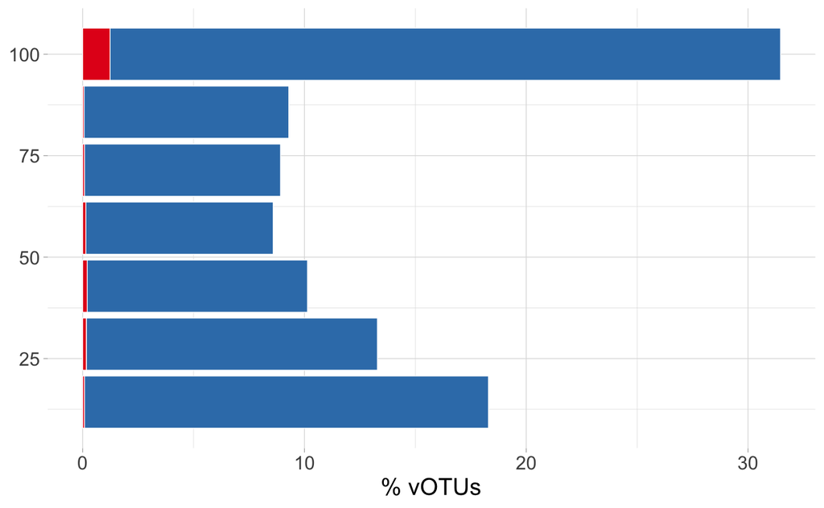

```r
v.occ.p <- v.occ.df.month %>%
  mutate(Set = fct_relevel(Set, "Virome")) %>%
  group_by(Set, Occupancy2) %>%
  dplyr::count() %>%
  ungroup() %>%
  mutate(pOTU = n/sum(n) * 100) %>%
  ggplot(aes(Occupancy2, pOTU, fill = Set, color = Set)) +
  geom_bar(stat = "identity", color = "white", size = 0.25) +
  scale_fill_brewer(palette = "Set1", direction = -1) +
  scale_color_manual(values = c(RColorBrewer::brewer.pal(3, "Set1")[2],"gray25")) +
  scale_x_continuous(breaks = c(0, 25, 50, 75, 100)) +
  coord_flip() +
  ylab("% vOTUs") +
  theme_light() +
  theme(text = element_text(size = 15),
        #axis.text.y = element_blank(),
        axis.title.y = element_blank(),
        panel.border = element_blank(),
        legend.position = "none")
v.occ.p
```

Plot abundance density plots

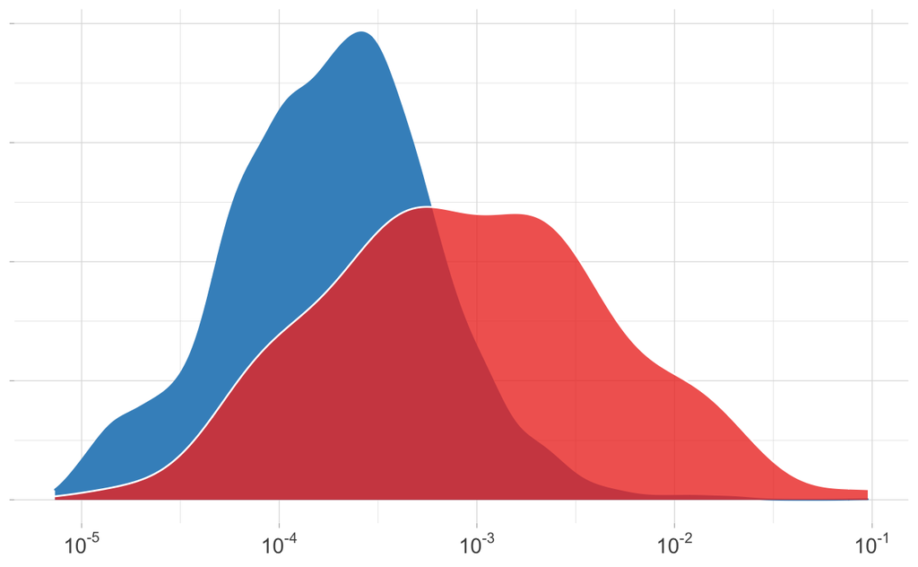

```r
v.ab.p <- v.occ.df.month %>%
  ggplot(aes(MeanAbundance)) +
  geom_density(fill = pal[2], color = pal[2]) +
  geom_density(data = filter(v.occ.df.month, Set == "Both"), fill = pal[1], color = "white", alpha = 0.8) +
  xlab("Mean Abundance (log10)") +
  ylab("Density") +
  scale_y_continuous() +
  scale_x_log10(labels = scales::trans_format("log10", scales::math_format(10^.x))) +
  theme_light() +
  theme(text = element_text(size = 15),
        axis.text.y= element_blank(),
        axis.title = element_blank(),
        panel.border = element_blank())
v.ab.p
```

Make final figure

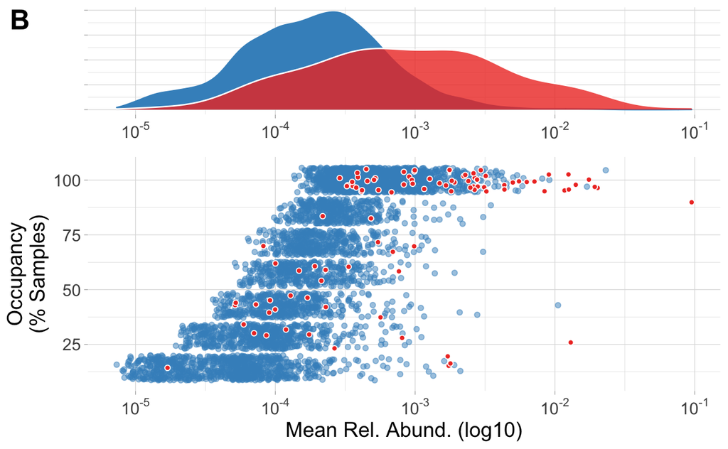

```r
left <- cowplot::plot_grid(v.ab.p, v.curve.p, nrow = 2, align = "v", rel_heights = c(1,2), labels = "B", label_size = 20)
left
```

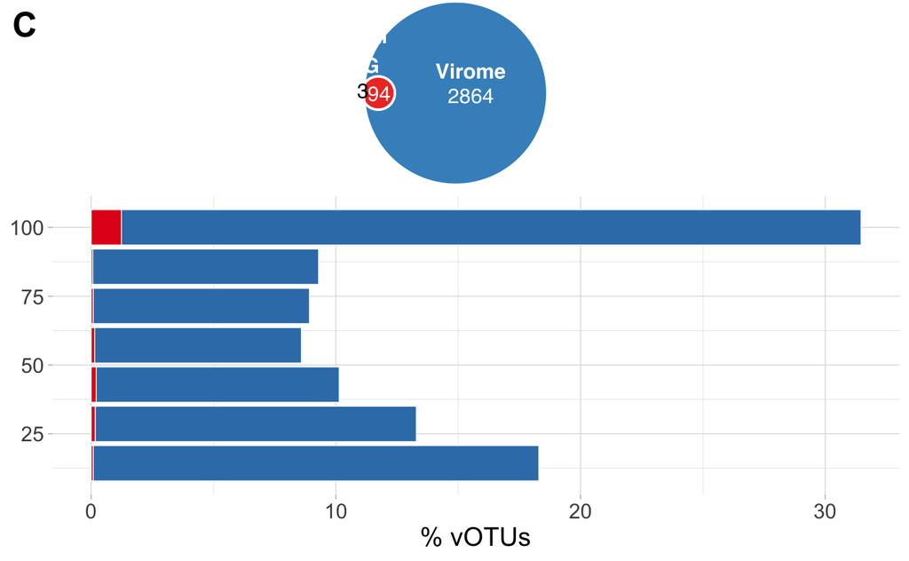

```r
right <- cowplot::plot_grid(euler.p, v.occ.p, nrow = 2, rel_heights = c(1,2), labels = "C", label_size = 20)
right
```

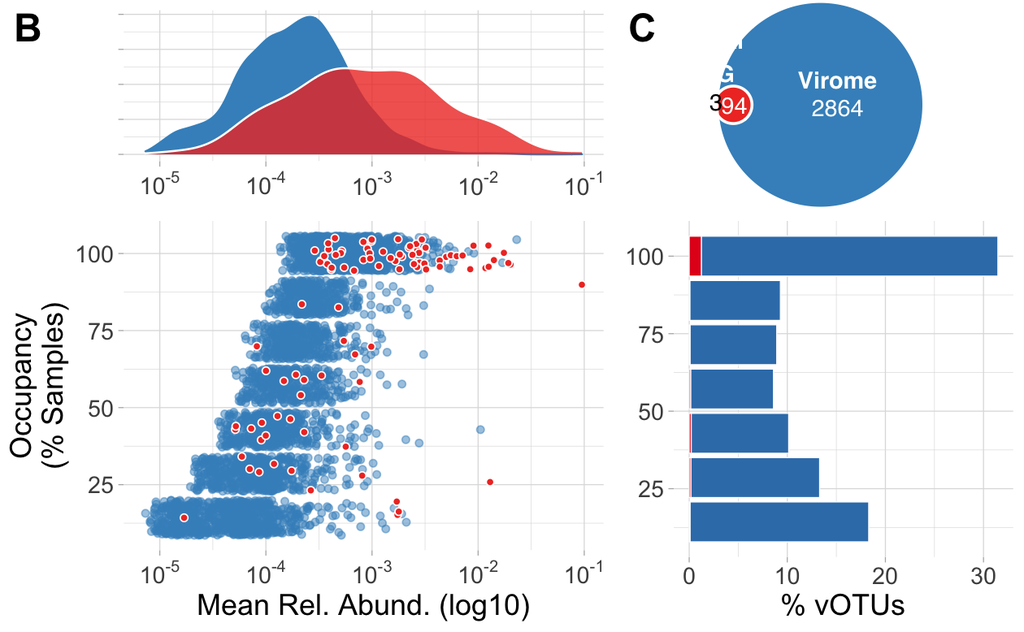

```r
bottom <- cowplot::plot_grid(left, right, nrow = 1, align = "h", axis = "tb", rel_widths = c(3,2))
bottom
```

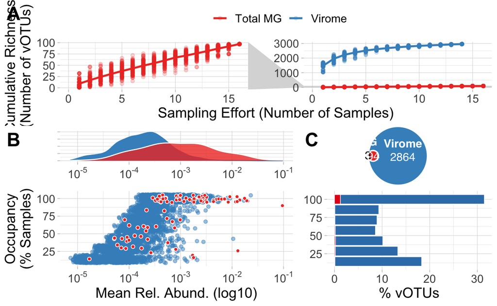

```r
###666:795
cowplot::plot_grid(acc.p, bottom, nrow = 2, rel_heights = c(7, 10), labels = "A", label_size = 20)
```

Abundance-occupancy patterns of vOTUs detected in viromes

```r
# Plot ab-occ curve
v.curve.p <- v.occ.df.month %>%
  ggplot(aes(MeanAbundance, Occupancy2)) +
  geom_jitter(color = "gray25", alpha =0.8, shape = 1) +
  xlab("Mean Rel. Abund. (log10)") +
  ylab("Occupancy\n(% Samples)") +
  scale_x_log10(labels = scales::trans_format("log10", scales::math_format(10^.x))) +
  theme_light() +
  theme(text = element_text(size = 15),
        panel.border = element_blank())

# Plot occupancy barplot
v.occ.p <- v.occ.df.month %>%
  group_by(Occupancy2) %>%
  dplyr::count() %>%
  ungroup() %>%
  mutate(pOTU = n/sum(n) * 100) %>%
  ggplot(aes(Occupancy2, pOTU)) +
  geom_bar(stat = "identity", size = 0.25, color = "gray25") +
  scale_x_continuous(breaks = c(0, 25, 50, 75, 100)) +
  coord_flip() +
  ylab("% vOTUs") +
  theme_light() +
  theme(text = element_text(size = 15),
        #axis.text.y = element_blank(),
        axis.title.y = element_blank(),
        panel.border = element_blank(),
        legend.position = "none")

# Plot abundance density curve
v.ab.p <- v.occ.df.month %>%
  ggplot(aes(MeanAbundance)) +
  geom_density(fill = "gray25", color = "gray25") +
  xlab("Mean Abundance (log10)") +
  ylab("Density") +
  scale_y_continuous() +
  scale_x_log10(labels = scales::trans_format("log10", scales::math_format(10^.x))) +
  theme_light() +
  theme(text = element_text(size = 15),
        axis.text.y= element_blank(),
        axis.title = element_blank(),
        panel.border = element_blank())

# Put plots together
v.left <- cowplot::plot_grid(v.ab.p, v.curve.p, nrow = 2, align = "v", rel_heights = c(1,2), label_size = 20)
v.right <- cowplot::plot_grid(NA, v.occ.p, nrow = 2, rel_heights = c(1,2), label_size = 20)
```

```
Cannot convert object of class logical into a grob.
```

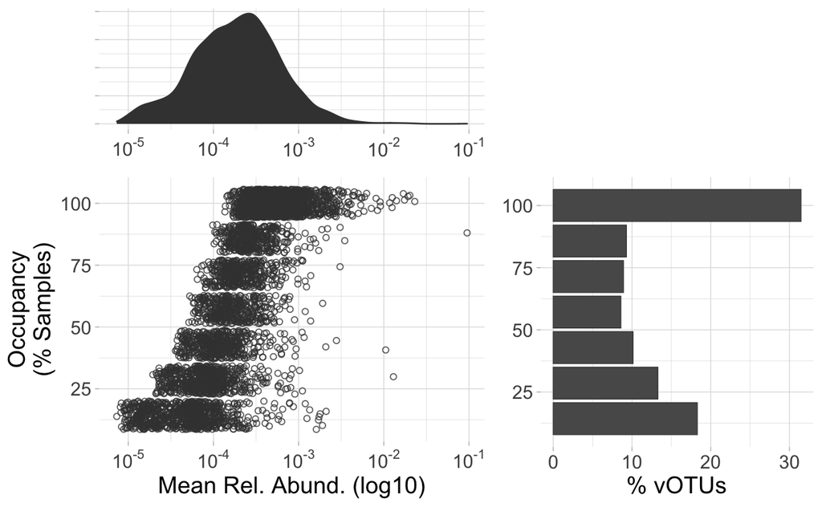

```r
v.vir <- cowplot::plot_grid(v.left, v.right, nrow = 1, align = "h", axis = "tb", rel_widths = c(3,2))
v.vir
```

Abundance-occupancy patterns of vOTUs detected in total MGs

```r
# Calculate occupancy and abundance within month subsets
b.occ.df.month <- b.otu.tidy %>%
  group_by(SampleID) %>%
  mutate(RelAbundance = Abundance/sum(Abundance)) %>%
  group_by(Month, OTU_ID) %>%
  summarise(Occupancy = sum(Abundance > 0),
            Occupancy2 = sum(Abundance > 0)/n() * 100,
            MeanAbundance = mean(RelAbundance),
            MeanRelAbundance = mean(RelAbundance)) %>%
  filter(Occupancy > 0) %>%
  inner_join(sets.per.month, by = c("Month", "OTU_ID"))
# Plot ab-occ curve
b.curve.p <- b.occ.df.month %>%
  ggplot(aes(MeanAbundance, Occupancy2)) +
  geom_jitter(color = "gray25", alpha =0.8, shape = 1) +
  xlab("Mean Rel. Abund. (log10)") +
  ylab("Occupancy\n(% Samples)") +
  ylim(0,100) +
  scale_x_log10(labels = scales::trans_format("log10", scales::math_format(10^.x))) +
  theme_light() +
  theme(text = element_text(size = 15),
        panel.border = element_blank())

# Plot occupancy barplot
b.occ.p <- b.occ.df.month %>%
  group_by(Occupancy2) %>%
  dplyr::count() %>%
  ungroup() %>%
  mutate(pOTU = n/sum(n) * 100) %>%
  ggplot(aes(Occupancy2, pOTU)) +
  geom_bar(stat = "identity", size = 0.25, color = "gray25") +
  scale_x_continuous(breaks = c(0, 25, 50, 75, 100)) +
  coord_flip() +
  xlim(0,100) +
  ylab("% vOTUs") +
  theme_light() +
  theme(text = element_text(size = 15),
        #axis.text.y = element_blank(),
        axis.title.y = element_blank(),
        panel.border = element_blank(),
        legend.position = "none")
# Plot abundance density curve
b.ab.p <- b.occ.df.month %>%
  ggplot(aes(MeanAbundance)) +
  geom_density(fill = "gray25", color = "gray25") +
  xlab("Mean Abundance (log10)") +
  ylab("Density") +
  scale_y_continuous() +
  scale_x_log10(labels = scales::trans_format("log10", scales::math_format(10^.x))) +
  theme_light() +
  theme(text = element_text(size = 15),
        axis.text.y= element_blank(),
        axis.title = element_blank(),
        panel.border = element_blank())

# Put plots together
b.left <- cowplot::plot_grid(b.ab.p, b.curve.p, nrow = 2, align = "v", rel_heights = c(1,2), label_size = 20)
b.right <- cowplot::plot_grid(NA, b.occ.p, nrow = 2, rel_heights = c(1,2), label_size = 20)
```

```
Cannot convert object of class logical into a grob.
```

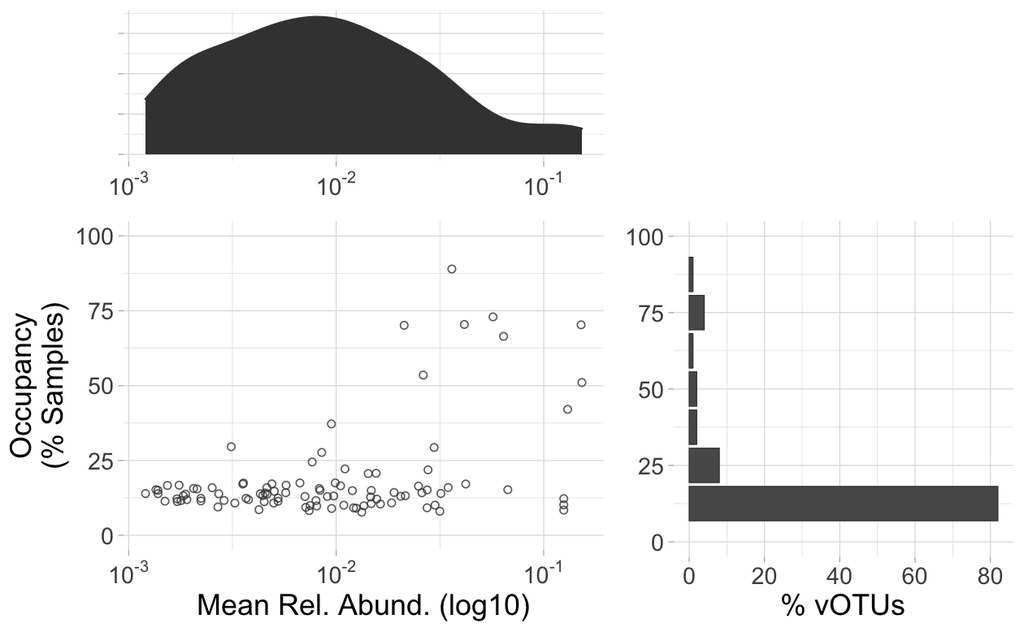

```r
b.vir <- cowplot::plot_grid(b.left, b.right, nrow = 1, align = "h", axis = "tb", rel_widths = c(3,2))
b.vir
```

Load and format 16S data

```r
rrna.otu <- readRDS("../Data/rrna_otu_filt.RDS")
rrna.otu.tidy <- tidy_otu(rrna.otu) %>%
  rename("Abundance" = "Count")

rrna.v.otu.tidy <- rrna.otu.tidy %>%
  inner_join(v.map, by = "SampleID")

rrna.b.otu.tidy <- rrna.otu.tidy %>%
  inner_join(b.map, by = "SampleID")
```

Abundance-occupancy patterns of 16S OTUs detected in viromes

```r
# Calculate occupancy and abundance within month subsets
rrna.v.occ.df.month <- rrna.v.otu.tidy %>%
  group_by(SampleID) %>%
  mutate(RelAbundance = Abundance/sum(Abundance)) %>%
  group_by(Month, OTU_ID) %>%
  summarise(Occupancy = sum(Abundance > 0),
            Occupancy2 = sum(Abundance > 0)/n() * 100,
            MeanAbundance = mean(RelAbundance),
            MeanRelAbundance = mean(RelAbundance)) %>%
  filter(Occupancy > 0)
# Plot ab-occ curve
rrna.v.curve.p <- rrna.v.occ.df.month %>%
  ggplot(aes(MeanAbundance, Occupancy2)) +
  geom_jitter(color = "gray25", alpha =0.8, shape = 1) +
  xlab("Mean Rel. Abund. (log10)") +
  ylab("Occupancy\n(% Samples)") +
  scale_x_log10(labels = scales::trans_format("log10", scales::math_format(10^.x))) +
  theme_light() +
  theme(text = element_text(size = 15),
        panel.border = element_blank())

# Plot occupancy barplot
rrna.v.occ.p <- rrna.v.occ.df.month %>%
  group_by(Occupancy2) %>%
  dplyr::count() %>%
  ungroup() %>%
  mutate(pOTU = n/sum(n) * 100) %>%
  ggplot(aes(Occupancy2, pOTU)) +
  geom_bar(stat = "identity", size = 0.25, color = "gray25") +
  scale_x_continuous(breaks = c(0, 25, 50, 75, 100)) +
  coord_flip() +
  ylab("% 16S OTUs") +
  theme_light() +
  theme(text = element_text(size = 15),
        axis.title.y = element_blank(),
        panel.border = element_blank(),
        legend.position = "none")

# Plot abundance density curve
rrna.v.ab.p <- rrna.v.occ.df.month %>%
  ggplot(aes(MeanAbundance)) +
  geom_density(fill = "gray25", color = "gray25") +
  xlab("Mean Abundance (log10)") +
  ylab("Density") +
  scale_y_continuous() +
  scale_x_log10(labels = scales::trans_format("log10", scales::math_format(10^.x))) +
  theme_light() +
  theme(text = element_text(size = 15),
        axis.text.y= element_blank(),
        axis.title = element_blank(),
        panel.border = element_blank())

# Put plots together
rrna.v.left <- cowplot::plot_grid(rrna.v.ab.p, rrna.v.curve.p, nrow = 2, align = "v", rel_heights = c(1,2), label_size = 20)
rrna.v.right <- cowplot::plot_grid(NA, rrna.v.occ.p, nrow = 2, rel_heights = c(1,2), label_size = 20)
```

```
Cannot convert object of class logical into a grob.
```

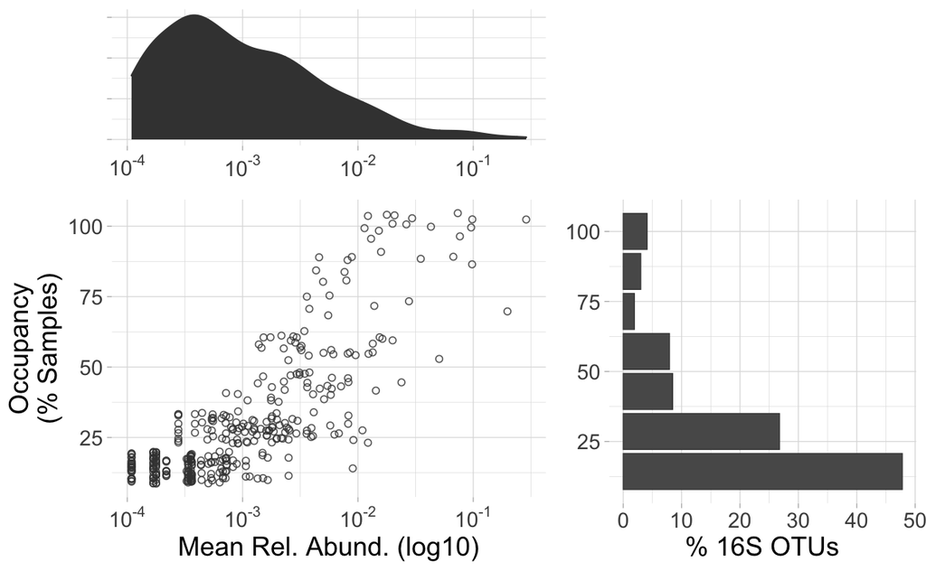

```r
rrna.v.vir <- cowplot::plot_grid(rrna.v.left, rrna.v.right, nrow = 1, align = "h", axis = "tb", rel_widths = c(3,2))
rrna.v.vir
```

Abundance-occupancy patterns of 16S OTUs detected in total MGs

```r
# Calculate occupancy and abundance within month subsets
rrna.b.occ.df.month <- rrna.b.otu.tidy %>%
  group_by(SampleID) %>%
  mutate(RelAbundance = Abundance/sum(Abundance)) %>%
  group_by(Month, OTU_ID) %>%
  summarise(Occupancy = sum(Abundance > 0),
            Occupancy2 = sum(Abundance > 0)/n() * 100,
            MeanAbundance = mean(RelAbundance),
            MeanRelAbundance = mean(RelAbundance)) %>%
  filter(Occupancy > 0)
# Plot ab-occ curve
rrna.b.curve.p <- rrna.b.occ.df.month %>%
  ggplot(aes(MeanAbundance, Occupancy2)) +
  geom_jitter(color = "gray25", alpha =0.8, shape = 1) +
  xlab("Mean Rel. Abund. (log10)") +
  ylab("Occupancy\n(% Samples)") +
  scale_x_log10(labels = scales::trans_format("log10", scales::math_format(10^.x))) +
  theme_light() +
  theme(text = element_text(size = 15),
        panel.border = element_blank())

# Plot occupancy barplot
rrna.b.occ.p <- rrna.b.occ.df.month %>%
  group_by(Occupancy2) %>%
  dplyr::count() %>%
  ungroup() %>%
  mutate(pOTU = n/sum(n) * 100) %>%
  ggplot(aes(Occupancy2, pOTU)) +
  geom_bar(stat = "identity", size = 0.25, color = "gray25") +
  scale_x_continuous(breaks = c(0, 25, 50, 75, 100)) +
  coord_flip() +
  ylab("% 16S OTUs") +
  theme_light() +
  theme(text = element_text(size = 15),
        axis.title.y = element_blank(),
        panel.border = element_blank(),
        legend.position = "none")

# Plot abundance density curve
rrna.b.ab.p <- rrna.b.occ.df.month %>%
  ggplot(aes(MeanAbundance)) +
  geom_density(fill = "gray25", color = "gray25") +
  xlab("Mean Abundance (log10)") +
  ylab("Density") +
  scale_y_continuous() +
  scale_x_log10(labels = scales::trans_format("log10", scales::math_format(10^.x))) +
  theme_light() +
  theme(text = element_text(size = 15),
        axis.text.y= element_blank(),
        axis.title = element_blank(),
        panel.border = element_blank())

# Put plots together
rrna.b.left <- cowplot::plot_grid(rrna.b.ab.p, rrna.b.curve.p, nrow = 2, align = "v", rel_heights = c(1,2), label_size = 20)
rrna.b.right <- cowplot::plot_grid(NA, rrna.b.occ.p, nrow = 2, rel_heights = c(1,2), label_size = 20)
```

```
Cannot convert object of class logical into a grob.
```

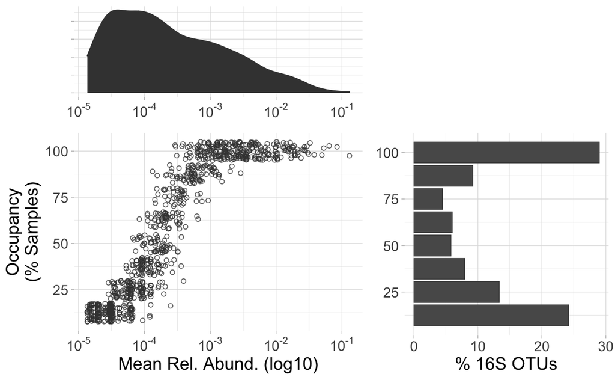

```r
rrna.b.vir <- cowplot::plot_grid(rrna.b.left, rrna.b.right, nrow = 1, align = "h", axis = "tb", rel_widths = c(3,2))
rrna.b.vir
```

Generate supplementary figure 5

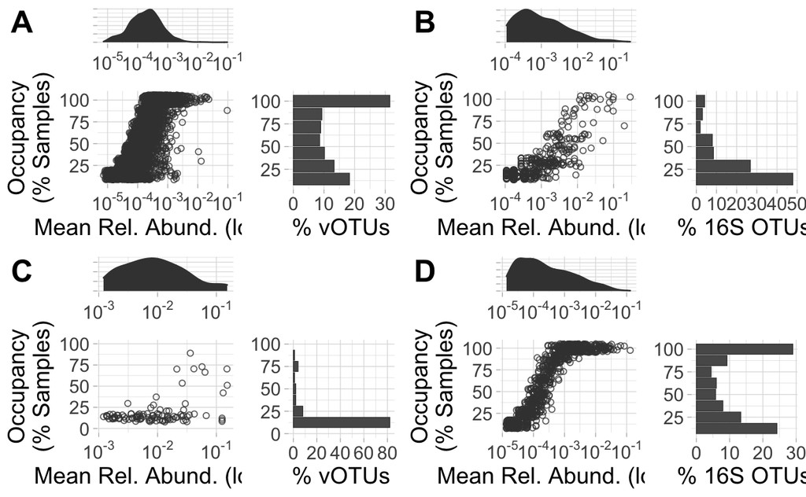

```r
cowplot::plot_grid(v.vir, rrna.v.vir, b.vir, rrna.b.vir,
                   labels = c("A", "B", "C", "D"), label_size = 20)
```

Generate alluvial plot comparing the vOTU ranked abundances across paired total MGs and viromes

```r
overlap <- v.ids[v.ids %in% b.ids]
overlap
```

```
 [1] "biochar_1094" "biochar_1128" "biochar_1160" "biochar_1347" "biochar_1482" "biochar_1527" "biochar_1554" "biochar_1567" "biochar_1579" "biochar_1710" "biochar_1815" "biochar_1822" "biochar_1861"
[14] "biochar_1988" "biochar_2056" "biochar_2058" "biochar_209"  "biochar_211"  "biochar_2135" "biochar_2280" "biochar_2295" "biochar_2339" "biochar_2366" "biochar_24"   "biochar_241"  "biochar_255"
[27] "biochar_2621" "biochar_2911" "biochar_3011" "biochar_3237" "biochar_3359" "biochar_3412" "biochar_3437" "biochar_368"  "biochar_3700" "biochar_3702" "biochar_3987" "biochar_4039" "biochar_435"
[40] "biochar_463"  "biochar_4808" "biochar_4878" "biochar_50"   "biochar_5344" "biochar_537"  "biochar_5382" "biochar_5681" "biochar_5760" "biochar_589"  "biochar_59"   "biochar_5905" "biochar_597"
[53] "biochar_64"   "biochar_658"  "biochar_664"  "biochar_685"  "biochar_840"  "biochar_874"  "biochar_897"  "biochar_1377" "biochar_1553" "biochar_1736" "biochar_1900" "biochar_2112" "biochar_2847"
[66] "biochar_2974" "biochar_3100" "biochar_332"  "biochar_3394" "biochar_347"  "biochar_5687" "biochar_5971" "biochar_69"   "biochar_754"  "biochar_785"  "biochar_995"  "biochar_1237" "biochar_4083"
[79] "biochar_447"  "biochar_464"  "biochar_933"  "biochar_2812" "biochar_2667" "biochar_3180" "biochar_33"   "biochar_3950" "biochar_471"  "biochar_3308" "biochar_40"   "biochar_432"  "biochar_4657"
[92] "biochar_2085" "biochar_1791" "biochar_2411"
```

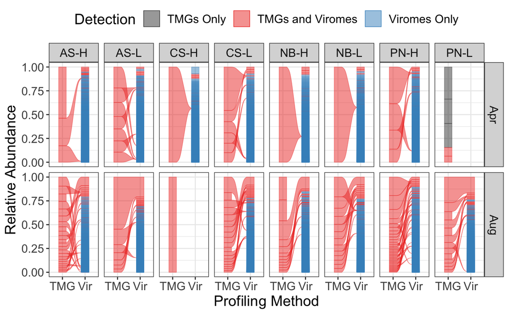

```r
# Generate data frame with vOTU relative abundances and indicate whether a vOTU is part of the 94 set of overlapping vOTUs across profilling methods.
alluvial.df <- otu %>%
  tidy_otu() %>%
  filter(Count > 0) %>%
  inner_join(map, by = "SampleID") %>%
  group_by(Extraction, Month, BchNtr) %>%
  mutate(RelAb = Count/sum(Count)) %>%
  ungroup() %>%
  mutate(Extraction = ifelse(Extraction == "BULK", "TMG", "Vir")) %>%
  mutate(Detection = ifelse(OTU_ID %in% overlap, "TMGs and Viromes",
                            ifelse(OTU_ID %in% v.ids, "Viromes Only", "TMGs Only"))) %>%
  mutate(Detection = fct_relevel(Detection, "TMGs Only", "TMGs and Viromes"))

# Plot
alluvial.p <- alluvial.df %>%
  ggplot(aes(Extraction, RelAb, alluvium = OTU_ID)) +
  geom_alluvium(aes(fill = Detection, color = Detection), decreasing = F, size = 0.25, alpha = 0.5) +
  scale_fill_manual(values = c("gray25", pal)) +
  scale_color_manual(values = c("gray25", pal)) +
  xlab("Profiling Method") +
  ylab("Relative Abundance") +
  facet_grid(Month ~ BchNtr) +
  theme_bw() +
  theme(text = element_text(size = 15),
        legend.position = "top")

alluvial.p
```